# R Notebook

# Intro

As the topic of the research I, as a big fan, chose chess. The dataset I used in the analysis was found in kaggle (https://www.kaggle.com/datasnaek/chess). It contains a set with over 20.000 chess games played in 2016-2018 at one of the most popular online chess platforms Lichess(https://lichess.org/). Each game includes the id of the players, the winner, the type of victory (checkmate, resigning, exceeded time limit or draw), number of turns, the ratings of the players, info about the opening and other cool stuff.

```r
library(ggplot2)
library(plyr)
library(ggcorrplot)
library(stringr)
library(fitdistrplus)
library(EnvStats)
data = read.csv("games.csv")
head(data)
```

|  | id | rated | created_at | last_move_at | turns | victory_status | winner | increment_code | white_id | white_rating | black_id | black_rating | moves | opening_eco | opening_name | opening_ply |
| --- | --- | --- | --- | --- | --- | --- | --- | --- | --- | --- | --- | --- | --- | --- | --- | --- |
| 1 | TZJHLljE | FALSE | 1.50421e+12 | 1.50421e+12 | 13 | outoftime | white | 15+2 | bourgris | 1500 | a-00 | 1191 | d4 d5 c4 c6 cxd5 e6 dxe6 fxe6 Nf3 Bb4+ Nc3 Ba5 Bf4 | D10 | Slav Defense: Exchange Variation | 5 |
| 2 | l1NXvwaE | TRUE | 1.50413e+12 | 1.50413e+12 | 16 | resign | black | 5+10 | a-00 | 1322 | skinnerua | 1261 | d4 Nc6 e4 e5 f4 f6 dxe5 fxe5 fxe5 Nxe5 Qd4 Nc6 Qe5+ Nxe5 c4 Bb4+ | B00 | Nimzowitsch Defense: Kennedy Variation | 4 |
| 3 | mIICvQHh | TRUE | 1.50413e+12 | 1.50413e+12 | 61 | mate | white | 5+10 | ischia | 1496 | a-00 | 1500 | e4 e5 d3 d6 Be3 c6 Be2 b5 Nd2 a5 a4 c5 axb5 Nc6 bxc6 Ra6 Nc4 a4 c3 a3 Nxa3 Rxa3 Rxa3 c4 dxc4 d5 cxd5 Qxd5 exd5 Be6 Ra8+ Ke7 Bc5+ Kf6 Bxf8 Kg6 Bxg7 Kxg7 dxe6 Kh6 exf7 Nf6 Rxh8 Nh5 Bxh5 Kg5 Rxh7 Kf5 Qf3… | C20 | King's Pawn Game: Leonardis Variation | 3 |
| 4 | kWKvrqYL | TRUE | 1.50411e+12 | 1.50411e+12 | 61 | mate | white | 20+0 | daniamurashov | 1439 | adivanov2009 | 1454 | d4 d5 Nf3 Bf5 Nc3 Nf6 Bf4 Ng4 e3 Nc6 Be2 Qd7 O-O O-O-O Nb5 Nb4 Rc1 Nxa2 Ra1 Nb4 Nxa7+ Kb8 Nb5 Bxc2 Bxc7+ Kc8 Qd2 Qc6 Na7+ Kd7 Nxc6 bxc6 Bxd8 Kxd8 Qxb4 e5 Qb8+ Ke7 dxe5 Be4 Ra7+ Ke6 Qe8+ Kf5 Qxf7+ Nf6 … | D02 | Queen's Pawn Game: Zukertort Variation | 3 |
| 5 | 9tXo1AUZ | TRUE | 1.50403e+12 | 1.50403e+12 | 95 | mate | white | 30+3 | nik221107 | 1523 | adivanov2009 | 1469 | e4 e5 Nf3 d6 d4 Nc6 d5 Nb4 a3 Na6 Nc3 Be7 b4 Nf6 Bg5 O-O b5 Nc5 Bxf6 Bxf6 Bd3 Qd7 O-O Nxd3 Qxd3 c6 a4 cxd5 Nxd5 Qe6 Nc7 Qg4 Nxa8 Bd7 Nc7 Rc8 Nd5 Qg6 Nxf6+ Qxf6 Rfd1 Re8 Qxd6 Bg4 Qxf6 gxf6 Rd3 Bxf3 Rxf… | C41 | Philidor Defense | 5 |
| 6 | MsoDV9wj | FALSE | 1.50424e+12 | 1.50424e+12 | 5 | draw | draw | 10+0 | trelynn17 | 1250 | franklin14532 | 1002 | e4 c5 Nf3 Qa5 a3 | B27 | Sicilian Defense: Mongoose Variation | 4 |

# Aim

Obviously, one the most outstanding thing we can do with this dataset is to try to predict the winner of the game. In order to do that, let’s decide what info in the dataframe can be used for such prediction. Let’s take a look at the correlation matrix constructed of relevant columns of dataframe.

# Correlation matrix

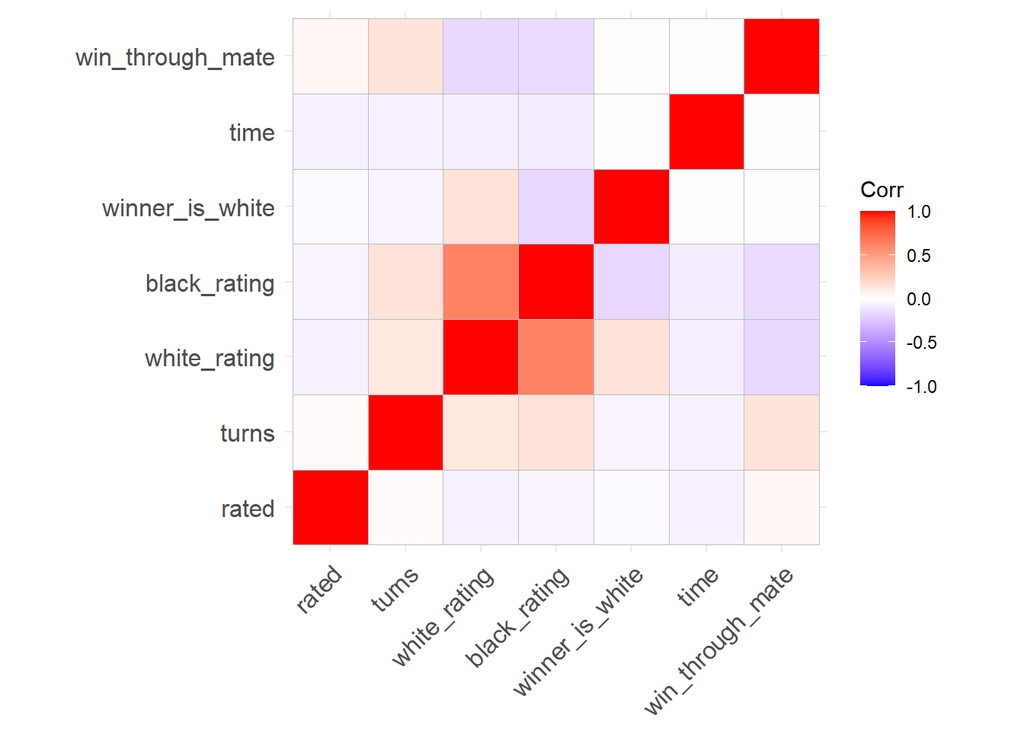

```r
# Clear the data, we are not interested in game played in draw
data = data[which(data$winner != "draw"), ]
data$time = as.integer(str_extract(data$increment_code, "\\d+")) # increment code
# is a convention of the given time for each player to make moves, by extracting
# the first part we get time for moves (second part is an additional time in
# seconds after each move is made)
data$winner_is_white = data$winner == "white" # need boolean values for creating
#corr matrix
data$win_through_mate = data$victory_status == "mate" # add new feauture))

data$rated = data$rated == "TRUE"
data = data[c("rated", "turns", "white_rating", "black_rating", "winner_is_white",
              "time", "win_through_mate")]
matrix = cor(data)
ggcorrplot(matrix)
```

Unfortunately, correlation matrix doesn’t show any significant dependency between the winner and some other features that could be used later in modeling logistic regression. Therefore, did we come to the dead end? Actually, there is a thing we could try to do as well. The ratings of white player and black separately doesn’t actually help our prediction. However, the difference between the player’s ratings seems like a logical thing to suggest, when trying to predict the outcome of the game. Let’s replace rating of white and black players with their difference and see how the correlation matrix changes.

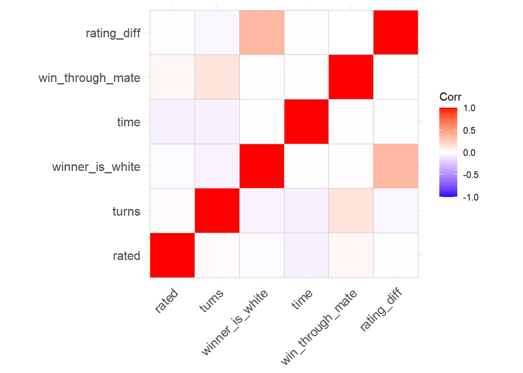

```r
data$rating_diff = data$white_rating - data$black_rating
data = data[c("rated", "turns", "winner_is_white", "time", "win_through_mate",
              "rating_diff")]
matrix = cor(data)
ggcorrplot(matrix)
```

That’s much better, the difference in ratings and the winner are indeed dependent. Before jumping straight to modeling our logistic regression, let’s analyze the distribution of the difference between ratings, as it’s our key to determining the winner and it is actually interesting to see how players are being selected at this online platform. My first suggestion is that the distribution is normal, as this selection should be carefully made usually with same rating of both players and with normal deviation (so it would be much more interest in game for both players).

# Distribution of rating difference

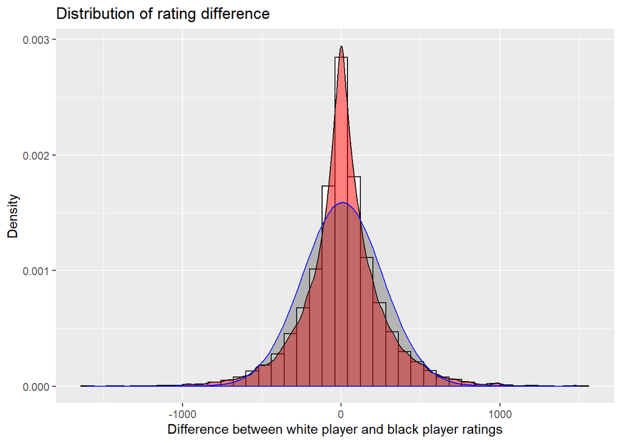

```r
ggplot(data, aes(x=rating_diff)) +
  geom_histogram(aes(y=..density..), color="black", fill="white", binwidth = 80) +
  geom_density(alpha=.5, fill="red") +
  stat_function(fun=dnorm, geom="area", args=list(mean=mean(data$rating_diff), sd=sd(data$rating_diff)), color="blue", alpha=.3) +
  labs(x="Difference between white player and black player ratings", y="Density",
       title="Distribution of rating difference")
```

Having a look at the density of our distribution, we can conclude that it really resembles normal one quite a lot, however it is much “peakier” than the normal. First of all, that should mean that the kurtosis of our distribution is much higher than in normal one (3), while skewness should be near 0 (because it is almost perfectly symmetrical). Take a look at the summary, to see it.

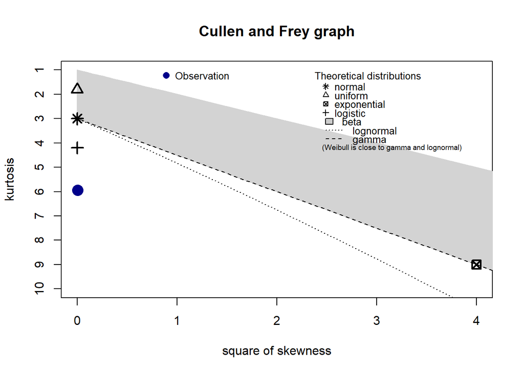

```
## summary statistics
## ------
## min:  -1605   max:  1499
## median:  3
## mean:  7.474304
## estimated sd:  250.6544
## estimated skewness:  0.07148698
## estimated kurtosis:  5.950324
```

```r
descdist(data$rating_diff)
```

Summary proves our assumptions made on the basis of plot. Cullen and Frey graph also suggests that our distribution is closer more to logistic than to a normal one. Therefore, I just googled logistic distribution and indeed: “It resembles the normal distribution in shape but has heavier tails (higher kurtosis).” And how surprised I was, when I saw that among different applications of logistic distribution, chess ratings are among them (recently United State Chess Federation switched from normal to logistic https://en.wikipedia.org/wiki/Logistic_distribution). Considering all said above, our hypothesis is that the distribution of rating difference is logistic. Before making any hasty decision, let’s conduct a more detailed visual analysis to see if we can relate our distribution to a logistic one.

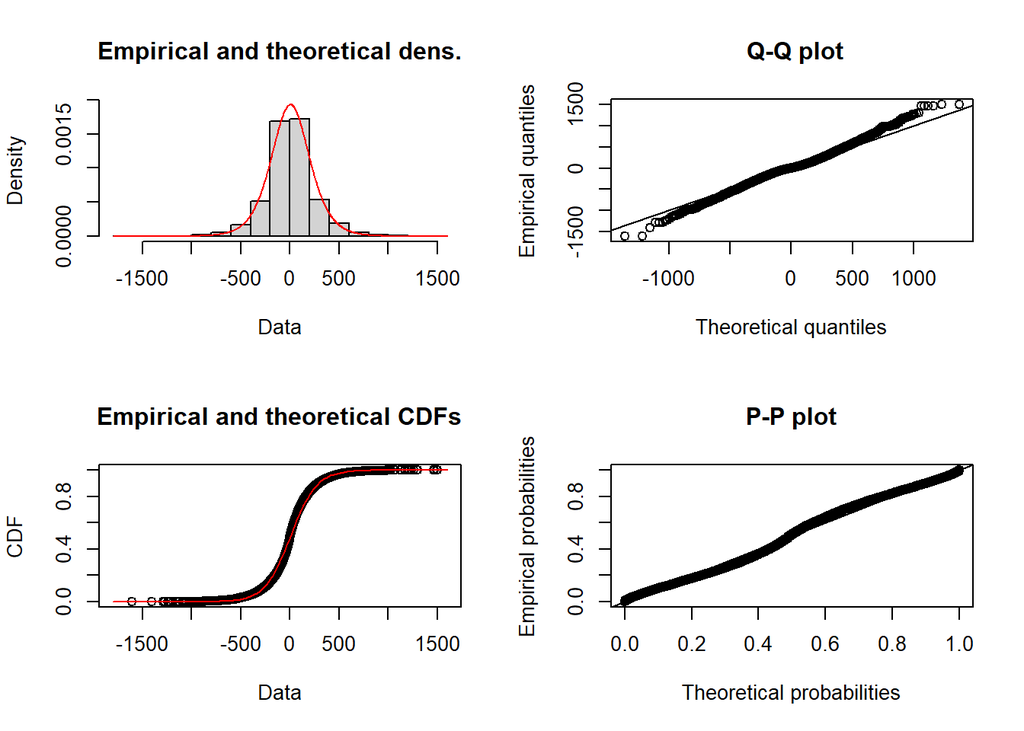

```r
fit.logistic = fitdist(data$rating_diff, "logis")
plot(fit.logistic)
```

Okay, the empirical cdf looks like converging to the theoretical one, Q-Q plot compares quantiles of our distribution and the theoretical one - they follow almost a straight line, which means that there is almost no deviation of our distribution from the theoretical logistic one. Similarly with P-P plot. Considering all of this, can we finally conclude that we are dealing with logistic distribution? Visualization techniques are always good, but, unfortunately, we can’t say anything for sure without a formal statistical test. Let’s carry out one! For testing the distribution family, we use a Kolgomorov-Smirnov test. By LLN, the empirical cdf should converge to the theoretical one, as sample size increases. By Glivenko–Cantelli theorem, the maximum difference between respective points of ecdf and theoretical cdf -> 0 with probability 1 uniformly. $\sup_{t\in R}|\hat{F_{x, n}}(t) - F_x(t)| -> 0$. Therefore, if this difference is small enough, we say that our distribution belongs to the family we assumed. That is the logic behind Kolgomorov-Smirnov test. (the point estimates of the parameters were calculated while fitting distribution, they will be used as parameters of the theoretical distribution). So, we test: $H_0:Distribution \quad belongs \quad to \quad logistic \quad family \quad \& \quad H_1: Distribution \quad doesn't \quad belong \quad to \quad logistic \quad family$

```r
#gofTest(data$rating_diff, distribution = "logis", test="ks")
ks.test(data$rating_diff, "plogis", fit.logistic$estimate[1], fit.logistic$estimate[2])
```

```
## Warning in ks.test(data$rating_diff, "plogis", fit.logistic$estimate[1], : ties
## should not be present for the Kolmogorov-Smirnov test
```

```
##
##  One-sample Kolmogorov-Smirnov test
##
## data:  data$rating_diff
## D = 0.047497, p-value < 2.2e-16
## alternative hypothesis: two-sided
```

As we see, the p-value is almost zero, therefore, without a doubt, we should reject $H_0$ For me, that seems quite strange, as, visually, our distribution behaves like a logistic one. First, I thought, that the problem is that actually we have a discrete distribution and we are trying to fit it in a continuous one. (because of it, we have many identical values (ties), which shouldn’t be present in a continuous case and test gives us actually this warning). I tried to add some error (has normal distribution with mean = 0 and small deviation) to the data to avoid ties, but it didn’t work out well. Secondly, I read that with large samples (this has over 15k elements and is considered large), Kolgomorov-Smirnov test almost always gives extremely low p-value (I think this is due to the fact of test’s sensitivity, i.e, when comparing cdf’s, we take into account only the maximum difference of them, which can probably be established by some outliers and their presence therefore crushes the whole test). I carried out a bunch of others goodness-of-fit tests, but the outcome, sadly, didn’t change. Finally, I tried reducing sample size and it worked out with the sample of size ~150, giving p-value more than 0.05 (that is considered the threshold when we can’t no longer reject null hypothesis). Don’t think it to be good enough though. The conclusion is that the distribution of rating difference doesn’t follow logistic distribution.